# Logistic Regression

## Introduction

- Motivation
- Data overview
- Perform logistic regression analysis
- Model evaluation

## Prepare data

**fev** data: Smoking tends to impair lung function. Data in children who smoke.

**age**: subject age

**smoke**: smoke smoking habits (1 = yes, 2 = no)

```r
#fev=read.csv("./data/fev.csv",header=TRUE,row.names=1)
fev <- read.csv("https://raw.githubusercontent.com/couthcommander/sip_computing/main/labs/fev.csv",header=TRUE,row.names=1)
fev$sex=ifelse(fev$sex==1,"male","female")
fev$smoke=factor(ifelse(fev$smoke==1,"yes","no"))

head(fev)
```

```
##   age   fev height    sex smoke
## 1   9 1.708   57.0 female    no
## 2   8 1.724   67.5 female    no
## 3   7 1.720   54.5 female    no
## 4   9 1.558   53.0   male    no
## 5   9 1.895   57.0   male    no
## 6   8 2.336   61.0 female    no
```

## Simple Logistic regression

**Question**: Does smoking associated with age?

### Logistic regression assumptions

- The outcome is a binary or dichotomous variable like yes vs no, positive vs negative, 1 vs 0.
- The Observations are Independent.
- There is a linear relationship between the logit of the outcome and each predictor variables. logit(p) = log($\frac{p}{1-p}$), where p is the probabilities of being the outcome (for example, being yes).
- There is no extreme values or outliers in the continuous predictors
- There is no high multicollinearity among the predictors.

### Data visulization

```r
table(fev$smoke)
```

```
##
##  no yes
## 589  65
```

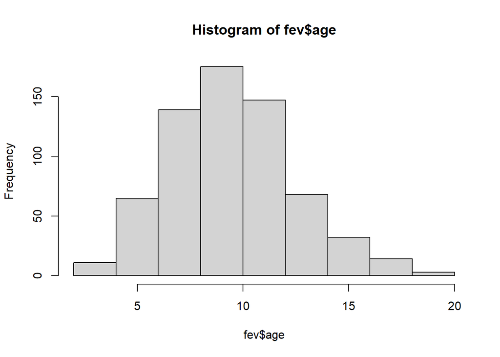

```r
hist(fev$age)
```

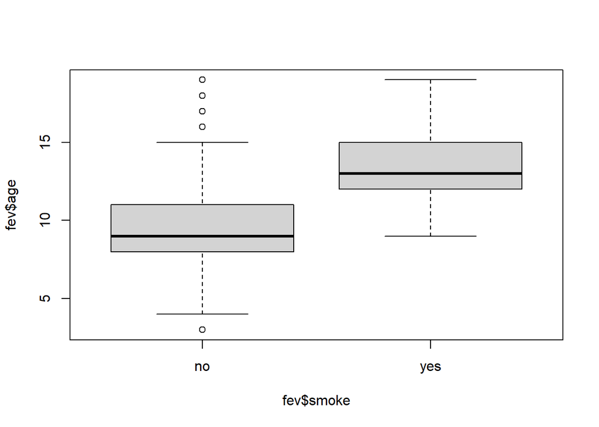

```r
boxplot(fev$age~fev$smoke)
```

### Perform logistic regression analysis

logit(p Smoking)=log($\frac{p}{1-p}$)=b0+b1*Age

```r
modelResult <- glm(smoke ~ age, data = fev,family = "binomial")
summary(modelResult)
```

```
##
## Call:
## glm(formula = smoke ~ age, family = "binomial", data = fev)
##
## Deviance Residuals:
##     Min       1Q   Median       3Q      Max
## -1.8204  -0.4120  -0.2574  -0.1595   2.6170
##
## Coefficients:
##             Estimate Std. Error z value Pr(>|z|)
## (Intercept) -7.74391    0.70890 -10.924   <2e-16 ***
## age          0.48364    0.05513   8.773   <2e-16 ***
## ---
## Signif. codes:  0 '***' 0.001 '**' 0.01 '*' 0.05 '.' 0.1 ' ' 1
##
## (Dispersion parameter for binomial family taken to be 1)
##
##     Null deviance: 423.45  on 653  degrees of freedom
## Residual deviance: 318.56  on 652  degrees of freedom
## AIC: 322.56
##
## Number of Fisher Scoring iterations: 6
```

Model Interpretation:

the *Coefficients* estimates of the beta coefficients, Intercept (b0)=-7.74391 and age (b1)=0.48364

the standard errors (SE), which defines the accuracy of beta coefficients. For a given beta coefficient, the SE reflects how the coefficient varies under repeated sampling.

the z value and the associated p-value, which defines the statistical significance of the beta coefficients.

the estimated regression equation can be written as follow: log($\frac{p}{1-p}$) = -7.74391 + 0.48364*age

Alternatively, the equation can be written as: $\frac{e^{(-7.74391 + 0.48364* age)}}{1+e^{(-7.74391 + 0.48364* age)}}$

As a result, we can predict the probability (p) of being a smoker for a specific age value.

### Predict new data

```r
newData <- data.frame(age = c(Subject1=6,Subject2=16))
predictionResult=predict.glm(modelResult,newData,type ="response") #probabilities
predictionResult
```

```
##    Subject1    Subject2
## 0.007828938 0.498581315
```

### Odds ratio

logit(p Smoking)=log($\frac{p}{(1-p)}$) is also called as log-odds.

The $\frac{p}{(1-p)}$ is called odds, or odds of success. It reflect the likelihood that the event will occur. It can be seen as the ratio of “successes” to “non-successes”.

Odds ratio is the ratio between two odds:

$$\frac{(p1/(1-p1))}{(p2/(1-p2))}$$
It represents the ratio of the odds that an event will occur (for example, being a smoker) in one situation (for example, age = 2), compared to the odds of the event occurring (being a smoker) in the another situation (for example, age = 1). In this example, Odds ratio measures the association between a predictor variable (age) and the outcome variable (being smoker).

Based on the equation from model, log($\frac{p}{1-p}$) = -7.74391 + 0.48364*age. We can get the Odds Ratio between Age1 vs Age2: $e^{(-7.74391 + 0.48364*Age1)}/e^{(-7.74391 + 0.48364*Age2)}$

= $e^{(-7.74391 + 0.48364*Age1)-(7.74391 + 0.48364*Age2)}$

=$e^{0.48364*(Age1-Age2)}$

It indicates with one year age increase, the odds of being a smoker will increase $e^{0.48364*1}=1.62$

So we will report the odds ratio of Age by taking an exponential transformation of its coefficient. $e^{0.48364}=1.62$

```r
#odds ratio
exp(coefficients(modelResult))
```

```
##  (Intercept)          age
## 0.0004333759 1.6219666490
```

```r
#CI for odds ratio
exp(confint(modelResult))
```

```
##                    2.5 %      97.5 %
## (Intercept) 9.957013e-05 0.001616879
## age         1.462364e+00 1.816425554
```

## Multiple logistic regression

**Question**: Does smoking associated with age, height, and sex?

### Data visulization

```r
table(fev$sex,fev$smoke)
```

```
##
##           no yes
##   female 279  39
##   male   310  26
```

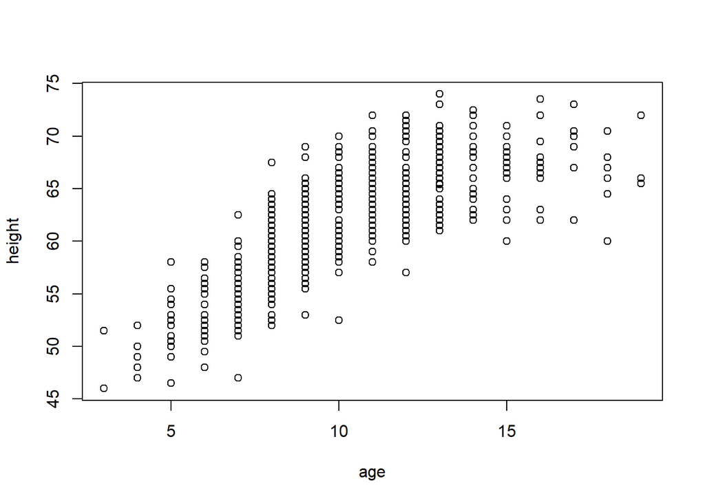

```r
plot(fev[,c("age","height")])
```

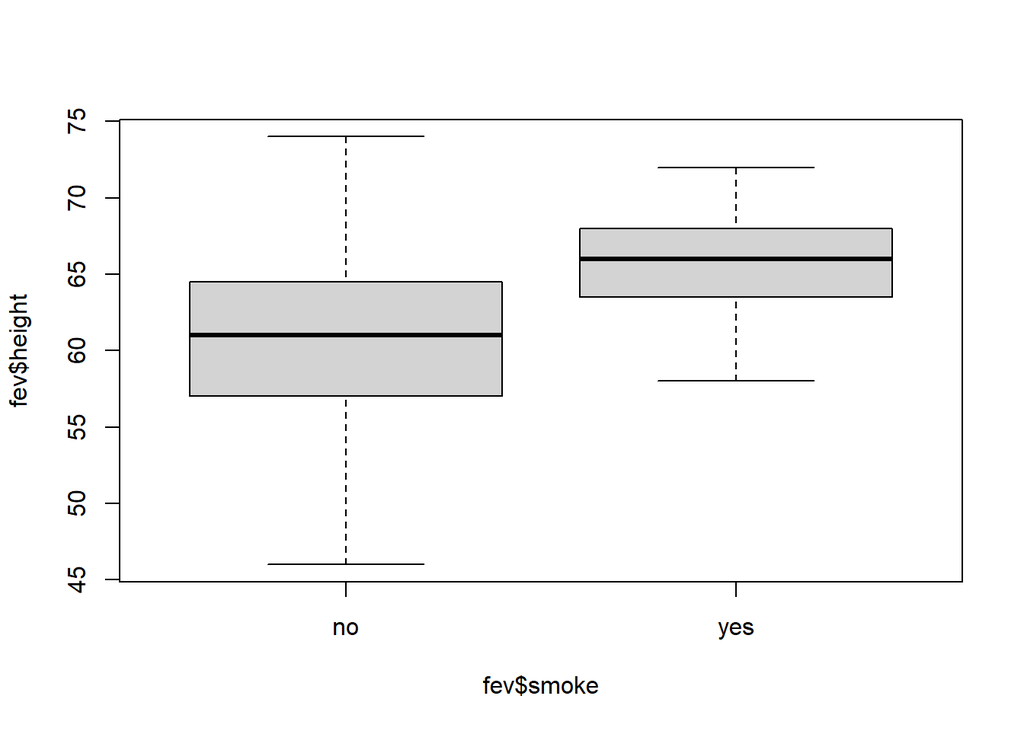

```r
boxplot(fev$height~fev$smoke)
```

### Perform logistic regression analysis

```r
modelResult <- glm(smoke ~ age+height+sex, data = fev,family = "binomial")
summary(modelResult)
```

```
##
## Call:
## glm(formula = smoke ~ age + height + sex, family = "binomial",
##     data = fev)
##
## Deviance Residuals:
##      Min        1Q    Median        3Q       Max
## -1.72393  -0.41038  -0.21198  -0.08289   3.12896
##
## Coefficients:
##              Estimate Std. Error z value Pr(>|z|)
## (Intercept) -15.88180    3.12163  -5.088 3.63e-07 ***
## age           0.39395    0.06703   5.877 4.18e-09 ***
## height        0.15182    0.05321   2.853 0.004329 **
## sexmale      -1.35698    0.38219  -3.551 0.000384 ***
## ---
## Signif. codes:  0 '***' 0.001 '**' 0.01 '*' 0.05 '.' 0.1 ' ' 1
##
## (Dispersion parameter for binomial family taken to be 1)
##
##     Null deviance: 423.45  on 653  degrees of freedom
## Residual deviance: 303.03  on 650  degrees of freedom
## AIC: 311.03
##
## Number of Fisher Scoring iterations: 7
```

### Effects of variables

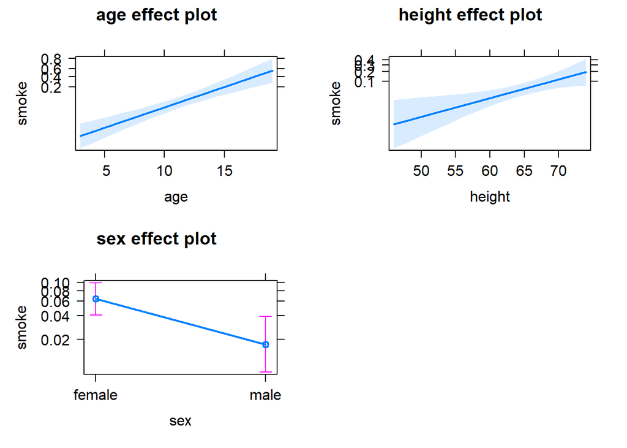

```r
library(effects)
plot(allEffects(modelResult),axes=list(x=list(rug=FALSE)))
```